# Perfiles productivos municipales en Colombia: k-medias vs k-medoides

Evaluaciones Agropecuarias Municipales (EVA) 2025 - UPRA

Pinzón Esteban, Barreto Alejandra

01 octubre, 2026

## 1. Contexto y objetivo

Los datos provienen de las Evaluaciones Agropecuarias Municipales (EVA), base agrícola 2019-2025, publicadas por la UPRA en datos.gov.co (código `uejq-wxrr`). El objetivo es agrupar los municipios de Colombia según su perfil productivo (tamaño, diversidad y composición del área sembrada) con **k-medias** y **k-medoides (PAM)**, y comparar ambos métodos.

Se trabaja solo con **2025** porque desde 2022 cambió la definición de área cosechada, producción y rendimiento de los cultivos transitorios, y mezclar años anteriores generaría incoherencias.

## 2. Librerías

```r
library(readr)
library(dplyr)
library(tidyr)
library(ggplot2)
library(cluster)
library(factoextra)
library(kableExtra)
library(reshape2)
library(gridExtra)
```

## 3. Lectura y limpieza

El CSV usa punto como separador de miles y coma como decimal (`1.007,00`), por eso se define la configuración regional.

```r
# Busca el CSV en la misma carpeta del .Rmd, sin depender del nombre exacto
archivo <- list.files(pattern = "Evaluaciones.*EVA.*\\.csv$", ignore.case = TRUE)[1]
stopifnot(!is.na(archivo))
archivo
```

```
## [1] "Evaluaciones_Agropecuarias_Municipales_–_EVA._2019_-_2025._Base_Agrícola_20260929.csv"
```

```r
eva <- read_csv(archivo,
                locale = locale(decimal_mark = ",", grouping_mark = ".", encoding = "UTF-8"),
                show_col_types = FALSE)

# Renombrar por posición para evitar problemas con tildes y espacios
names(eva) <- c("cod_dep","dep","cod_mun","mun","grupo","subgrupo","cultivo","desag",
                "anio","periodo","sembrada","cosechada","prod","rend","ciclo",
                "estado","cod_cultivo","cientifico")

dim(eva)
```

```
## [1] 166732     18
```

```r
glimpse(eva)
```

```
## Rows: 166,732
## Columns: 18
## $ cod_dep     <chr> "05", "05", "05", "05", "05", "05", "05", "05", "05", "05"…
## $ dep         <chr> "Antioquia", "Antioquia", "Antioquia", "Antioquia", "Antio…
## $ cod_mun     <chr> "05001", "05001", "05001", "05001", "05001", "05001", "050…
## $ mun         <chr> "Medellín", "Medellín", "Medellín", "Medellín", "Medellín"…
## $ grupo       <chr> "Hortalizas", "Hortalizas", "Hortalizas", "Hortalizas", "H…
## $ subgrupo    <chr> "Hortalizas de tallo", "Hortalizas de tallo", "Hortalizas …
## $ cultivo     <chr> "Apio", "Apio", "Apio", "Apio", "Apio", "Apio", "Apio", "A…
## $ desag       <chr> "Apio", "Apio", "Apio", "Apio", "Apio", "Apio", "Apio", "A…
## $ anio        <dbl> 2021, 2021, 2022, 2022, 2023, 2023, 2024, 2024, 2025, 2025…
## $ periodo     <chr> "2021A", "2021B", "2022A", "2022B", "2023A", "2023B", "202…
## $ sembrada    <dbl> 8.00, 8.00, 8.00, 8.00, 8.00, 8.00, 6.00, 7.00, 5.50, 7.00…
## $ cosechada   <dbl> 8.00, 8.00, 8.00, 8.00, 7.00, 8.00, 5.70, 6.60, 5.50, 7.00…
## $ prod        <dbl> 128.00, 152.00, 127.44, 152.00, 133.00, 152.00, 108.30, 12…
## $ rend        <dbl> 16.00, 19.00, 15.93, 19.00, 19.00, 19.00, 19.00, 19.00, 19…
## $ ciclo       <chr> "Transitorio", "Transitorio", "Transitorio", "Transitorio"…
## $ estado      <chr> "En fresco", "En fresco", "En fresco", "En fresco", "En fr…
## $ cod_cultivo <dbl> 1050600, 1050600, 1050600, 1050600, 1050600, 1050600, 1050…
## $ cientifico  <chr> "Apium graveolens", "Apium graveolens", "Apium graveolens"…
```

### 3.1 Revisión de la lectura y de los valores faltantes

```r
# >>> NUEVO: problemas de lectura (debe salir una tabla vacía)
problems(eva)
```

```
## # A tibble: 0 × 5
## # ℹ 5 variables: row <int>, col <int>, expected <chr>, actual <chr>, file <chr>
```

```r
# >>> NUEVO: conteos que cita el reporte (1.103 municipios, 32 departamentos, 165 cultivos)
data.frame(municipios    = n_distinct(eva$cod_mun),
           departamentos = n_distinct(eva$cod_dep),
           cultivos      = n_distinct(eva$cultivo))
```

```
##   municipios departamentos cultivos
## 1       1103            32      165
```

```r
# >>> NUEVO: valores faltantes en 2025 (si 'sembrada' tiene NA, hay que decidir qué hacer)
d25_check <- eva %>% filter(anio == 2025)
colSums(is.na(d25_check[, c("sembrada", "ciclo", "grupo", "cultivo")]))
```

```
## sembrada    ciclo    grupo  cultivo
##        0        0        0        0
```

```r
# >>> NUEVO: municipio(s) que están en el archivo pero no tienen datos en 2025
eva %>% filter(!cod_mun %in% d25_check$cod_mun) %>% distinct(cod_dep, dep, cod_mun, mun)
```

```
## # A tibble: 1 × 4
##   cod_dep dep       cod_mun mun
##   <chr>   <chr>     <chr>   <chr>
## 1 08      Atlántico 08372   Juan de Acosta
```

```r
# >>> NUEVO: área sembrada total 2025 por ciclo (reporte: 3,45 M permanentes y 2,15 M transitorios)
d25_check %>%
  group_by(ciclo) %>%
  summarise(hectareas = sum(sembrada, na.rm = TRUE)) %>%
  bind_rows(tibble(ciclo = "TOTAL", hectareas = sum(d25_check$sembrada, na.rm = TRUE)))
```

```
## # A tibble: 3 × 2
##   ciclo       hectareas
##   <chr>           <dbl>
## 1 Permanente   3449551.
## 2 Transitorio  2151376.
## 3 TOTAL        5600928.
```

## 4. Construcción de la matriz municipal (2025)

Cada fila es un municipio. Variables cuantitativas:

- `log_area`: logaritmo del área sembrada total (ha). El logaritmo corrige la fuerte asimetría.
- `n_cultivos`: número de cultivos distintos.
- `pct_perm`: proporción del área en cultivos permanentes.
- `pct_cereales`, `pct_frutales`, `pct_tropicales`, `pct_raices`, `pct_hortalizas`: proporción del área por grupo de cultivo.

```r
d25 <- eva %>% filter(anio == 2025)

base <- d25 %>%
  group_by(cod_mun, mun, dep) %>%
  summarise(area_total = sum(sembrada),
            n_cultivos = n_distinct(cultivo),
            area_perm  = sum(sembrada[ciclo == "Permanente"]),
            .groups = "drop")

grupos <- d25 %>%
  mutate(g = case_when(
    grupo == "Cereales" ~ "cereales",
    grupo == "Frutales" ~ "frutales",
    grupo == "Cultivos tropicales tradicionales" ~ "tropicales",
    grupo == "Raíces y tubérculos" ~ "raices",
    grupo == "Hortalizas" ~ "hortalizas",
    TRUE ~ "otros")) %>%
  group_by(cod_mun, g) %>%
  summarise(a = sum(sembrada), .groups = "drop") %>%
  pivot_wider(names_from = g, values_from = a, values_fill = 0)

# >>> NUEVO: avisa si algún municipio quedaría con área NA (se perdería en silencio en el filtro)
sum(is.na(base$area_total))
```

```
## [1] 0
```

```r
mun <- base %>%
  left_join(grupos, by = "cod_mun") %>%
  filter(area_total > 0) %>%
  mutate(log_area       = log(area_total),
         pct_perm       = area_perm / area_total,
         pct_cereales   = cereales / area_total,
         pct_frutales   = frutales / area_total,
         pct_tropicales = tropicales / area_total,
         pct_raices     = raices / area_total,
         pct_hortalizas = hortalizas / area_total)

vars <- c("log_area","n_cultivos","pct_perm","pct_cereales",
          "pct_frutales","pct_tropicales","pct_raices","pct_hortalizas")

df <- as.data.frame(mun[, vars])
rownames(df) <- mun$cod_mun
nrow(df)
```

```
## [1] 1102
```

## 5. Análisis exploratorio

```r
summary(df) %>% kable() %>% kable_styling(bootstrap_options = c("striped","condensed"))
```

|  | log_area | n_cultivos | pct_perm | pct_cereales | pct_frutales | pct_tropicales | pct_raices | pct_hortalizas |
| --- | --- | --- | --- | --- | --- | --- | --- | --- |
|  | Min. :-0.4308 | Min. : 2.00 | Min. :0.0000 | Min. :0.00000 | Min. :0.00000 | Min. :0.000000 | Min. :0.000000 | Min. :0.0000000 |
|  | 1st Qu.: 6.9476 | 1st Qu.:10.00 | 1st Qu.:0.2233 | 1st Qu.:0.01280 | 1st Qu.:0.05821 | 1st Qu.:0.009463 | 1st Qu.:0.007572 | 1st Qu.:0.0003576 |
|  | Median : 7.8189 | Median :14.00 | Median :0.7058 | Median :0.05665 | Median :0.15843 | Median :0.211166 | Median :0.040036 | Median :0.0085481 |
|  | Mean : 7.7441 | Mean :14.86 | Mean :0.5853 | Mean :0.16036 | Mean :0.22796 | Mean :0.317240 | Mean :0.145355 | Mean :0.0563017 |
|  | 3rd Qu.: 8.6538 | 3rd Qu.:18.00 | 3rd Qu.:0.9216 | 3rd Qu.:0.23257 | 3rd Qu.:0.34207 | 3rd Qu.:0.591586 | 3rd Qu.:0.196183 | 3rd Qu.:0.0509718 |
|  | Max. :12.3123 | Max. :50.00 | Max. :1.0000 | Max. :0.98863 | Max. :0.98379 | Max. :0.997748 | Max. :0.979931 | Max. :1.0000000 |

```r
# >>> NUEVO: media y desviación estándar de la Tabla 1 del reporte
data.frame(Variable = vars,
           Media    = sapply(df, mean),
           Desv_est = sapply(df, sd)) %>%
  kable(digits = 2, row.names = FALSE, caption = "Tabla 1: media y desviación estándar") %>%
  kable_styling(bootstrap_options = "striped", full_width = FALSE)
```

Tabla 1: media y desviación estándar

| Variable | Media | Desv_est |
| --- | --- | --- |
| log_area | 7.74 | 1.35 |
| n_cultivos | 14.86 | 6.77 |
| pct_perm | 0.59 | 0.36 |
| pct_cereales | 0.16 | 0.22 |
| pct_frutales | 0.23 | 0.21 |
| pct_tropicales | 0.32 | 0.31 |
| pct_raices | 0.15 | 0.21 |
| pct_hortalizas | 0.06 | 0.12 |

Efecto del logaritmo sobre el área total:

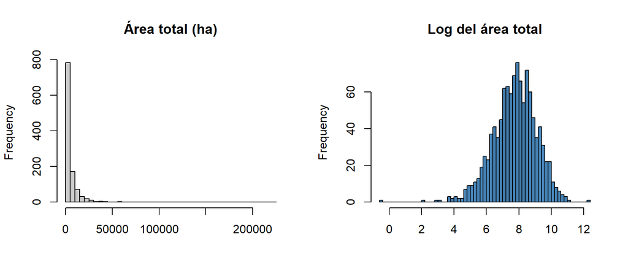

```r
par(mfrow = c(1, 2))
hist(mun$area_total, breaks = 50, main = "Área total (ha)", xlab = "", col = "grey80")
hist(mun$log_area,   breaks = 50, main = "Log del área total", xlab = "", col = "steelblue")
```

```r
par(mfrow = c(1, 1))
```

```r
# >>> NUEVO: asimetría antes y después del logaritmo (reporte: 12,0 y -0,5)
asim <- function(x) { x <- x - mean(x); mean(x^3) / mean(x^2)^1.5 }
data.frame(Variable  = c("area_total", "log_area"),
           Asimetria = c(asim(mun$area_total), asim(mun$log_area)),
           Mediana   = c(median(mun$area_total), median(mun$log_area))) %>%
  kable(digits = 2)
```

| Variable | Asimetria | Mediana |
| --- | --- | --- |
| area_total | 12.01 | 2487.27 |
| log_area | -0.53 | 7.82 |

```r
# >>> NUEVO: municipio con mayor área sembrada (reporte: Puerto Gaitán)
mun %>% slice_max(area_total, n = 1) %>% select(dep, mun, area_total)
```

```
## # A tibble: 1 × 3
##   dep   mun           area_total
##   <chr> <chr>              <dbl>
## 1 Meta  Puerto Gaitán    222416.
```

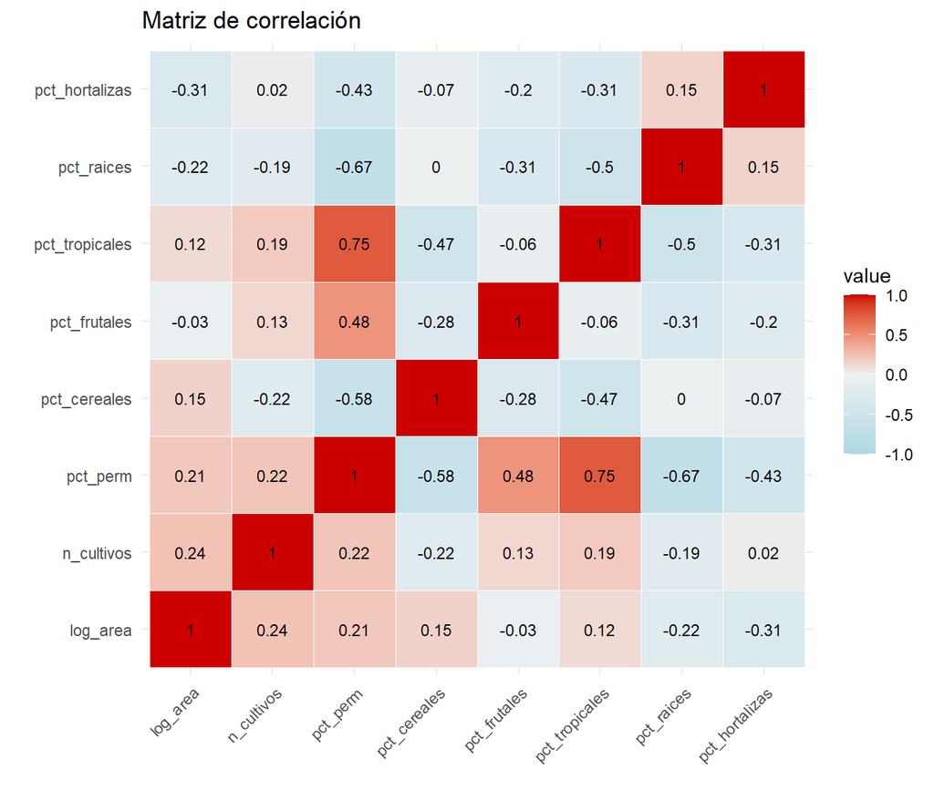

```r
corr <- melt(cor(df))
ggplot(corr, aes(Var1, Var2, fill = value)) +
  geom_tile(color = "white") +
  geom_text(aes(label = round(value, 2)), size = 3) +
  scale_fill_gradient2(low = "lightblue", mid = "#ECF0F1", high = "red3",
                       midpoint = 0, limits = c(-1, 1)) +
  theme_minimal() +
  theme(axis.text.x = element_text(angle = 45, hjust = 1)) +
  labs(title = "Matriz de correlación", x = "", y = "")
```

## 6. Estandarización

Se estandarizan todas las variables (media 0, desviación 1) para que ninguna domine la distancia.

```r
df_z <- scale(df)
```

### 6.1 Valores atípicos

```r
# >>> NUEVO: municipios con algún valor a más de 4 desviaciones de la media
z_max <- apply(abs(df_z), 1, max)
atip  <- names(z_max[z_max > 4])
length(atip)
```

```
## [1] 20
```

```r
mun %>%
  filter(cod_mun %in% atip) %>%
  select(dep, mun, area_total, n_cultivos, pct_perm, pct_hortalizas) %>%
  kable(digits = 2, caption = "Municipios con valores extremos (|z| > 4)") %>%
  kable_styling(bootstrap_options = "striped")
```

Municipios con valores extremos (|z| > 4)

| dep | mun | area_total | n_cultivos | pct_perm | pct_hortalizas |
| --- | --- | --- | --- | --- | --- |
| Antioquia | Guarne | 529.92 | 9 | 0.24 | 0.60 |
| Antioquia | El Santuario | 2840.24 | 26 | 0.05 | 0.56 |
| Atlántico | Barranquilla | 0.65 | 4 | 0.03 | 0.46 |
| Boyacá | Aquitania | 4517.91 | 11 | 0.02 | 0.95 |
| Boyacá | Corrales | 130.40 | 14 | 0.19 | 0.68 |
| Boyacá | Cuítiva | 340.50 | 8 | 0.10 | 0.57 |
| Boyacá | Duitama | 419.62 | 21 | 0.15 | 0.63 |
| Boyacá | Villa de Leyva | 1199.97 | 14 | 0.05 | 0.65 |
| Boyacá | Nobsa | 304.50 | 19 | 0.04 | 0.84 |
| Boyacá | Sáchica | 276.00 | 2 | 0.00 | 1.00 |
| Boyacá | Tibasosa | 725.50 | 13 | 0.06 | 0.84 |
| Córdoba | La Apartada | 596.66 | 13 | 0.03 | 0.71 |
| Cundinamarca | Cajicá | 294.05 | 19 | 0.02 | 0.59 |
| Cundinamarca | Cota | 895.64 | 14 | 0.00 | 0.60 |
| Cundinamarca | Fómeque | 765.17 | 7 | 0.23 | 0.66 |
| Cundinamarca | Mosquera | 3672.30 | 20 | 0.01 | 0.74 |
| Huila | Pital | 7598.05 | 44 | 0.86 | 0.02 |
| Magdalena | Fundación | 7344.20 | 50 | 0.56 | 0.10 |
| Santander | Tona | 4545.10 | 15 | 0.18 | 0.60 |
| Santander | Vetas | 7.50 | 9 | 0.24 | 0.00 |

## 7. Número de grupos

```r
# >>> CORREGIDO: antes se usaba fviz_nbclust, que corre k-medias con UNA sola
# inicialización y PAM con distancia euclidiana (distinto al PAM final con Manhattan).
# Ahora se usan exactamente los mismos ajustes que en los modelos finales.
ks    <- 2:10
d_euc <- dist(df_z)                        # para la silueta (igual que en la sección 10)
d_man <- dist(df_z, method = "manhattan")  # para PAM

tabla_k <- bind_rows(lapply(ks, function(kk) {
  set.seed(2026)
  km_k  <- kmeans(df_z, centers = kk, nstart = 50, iter.max = 50)
  pam_k <- pam(d_man, k = kk, diss = TRUE)
  data.frame(k           = kk,
             inercia     = km_k$tot.withinss,
             sil_kmedias = mean(silhouette(km_k$cluster, d_euc)[, 3]),
             sil_pam     = mean(silhouette(pam_k$clustering, d_euc)[, 3]),
             sil_pam_man = pam_k$silinfo$avg.width)
}))

tabla_k %>%
  kable(digits = 3, caption = "Tabla 2: inercia y silueta media según k") %>%
  kable_styling(bootstrap_options = "striped", full_width = FALSE)
```

Tabla 2: inercia y silueta media según k

| k | inercia | sil_kmedias | sil_pam | sil_pam_man |
| --- | --- | --- | --- | --- |
| 2 | 6125.886 | 0.313 | 0.313 | 0.369 |
| 3 | 5142.662 | 0.307 | 0.273 | 0.310 |
| 4 | 4389.598 | 0.255 | 0.247 | 0.258 |
| 5 | 3815.693 | 0.267 | 0.251 | 0.255 |
| 6 | 3381.303 | 0.272 | 0.185 | 0.199 |
| 7 | 3098.790 | 0.271 | 0.191 | 0.207 |
| 8 | 2850.110 | 0.277 | 0.184 | 0.198 |
| 9 | 2688.948 | 0.262 | 0.195 | 0.203 |
| 10 | 2547.267 | 0.265 | 0.210 | 0.215 |

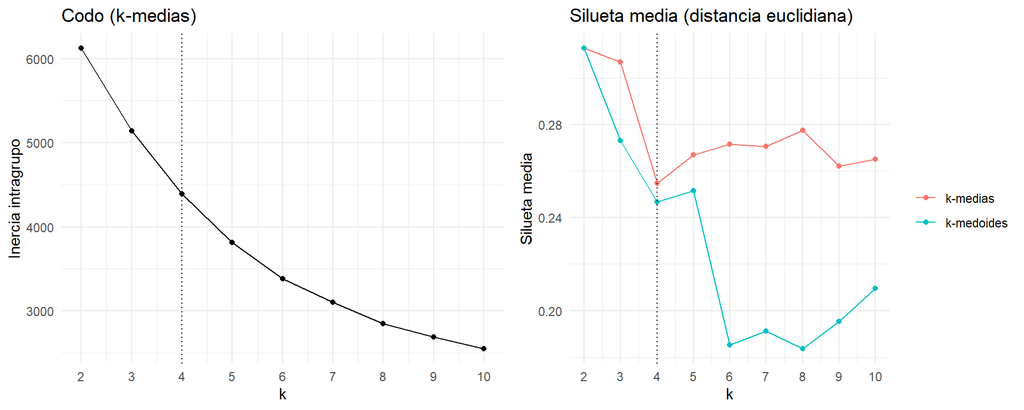

```r
g_codo <- ggplot(tabla_k, aes(k, inercia)) +
  geom_line() + geom_point() +
  geom_vline(xintercept = 4, linetype = "dotted") +
  scale_x_continuous(breaks = ks) + theme_minimal() +
  labs(title = "Codo (k-medias)", y = "Inercia intragrupo")

g_sil <- tabla_k %>%
  pivot_longer(c(sil_kmedias, sil_pam), names_to = "metodo", values_to = "silueta") %>%
  mutate(metodo = recode(metodo, sil_kmedias = "k-medias", sil_pam = "k-medoides")) %>%
  ggplot(aes(k, silueta, color = metodo)) +
  geom_line() + geom_point() +
  geom_vline(xintercept = 4, linetype = "dotted") +
  scale_x_continuous(breaks = ks) + theme_minimal() +
  labs(title = "Silueta media (distancia euclidiana)", y = "Silueta media", color = "")

grid.arrange(g_codo, g_sil, ncol = 2)
```

```r
# >>> NUEVO: qué pasa con k = 2 y k = 3 (justifica la elección de k = 4 en el reporte)
for (kk in 2:3) {
  set.seed(2026)
  km_k <- kmeans(df_z, centers = kk, nstart = 50)
  cat("\n--- k =", kk, "---\n")
  print(mun %>%
          mutate(g = km_k$cluster) %>%
          group_by(g) %>%
          summarise(n = n(),
                    pct_perm   = round(mean(pct_perm), 2),
                    pct_frut   = round(mean(pct_frutales), 2),
                    pct_trop   = round(mean(pct_tropicales), 2),
                    pct_cer    = round(mean(pct_cereales), 2),
                    pct_raices = round(mean(pct_raices), 2)))
}
```

```
##
## --- k = 2 ---
## # A tibble: 2 × 7
##       g     n pct_perm pct_frut pct_trop pct_cer pct_raices
##   <int> <int>    <dbl>    <dbl>    <dbl>   <dbl>      <dbl>
## 1     1   451     0.19     0.12     0.05    0.31       0.3
## 2     2   651     0.86     0.31     0.5     0.06       0.04
##
## --- k = 3 ---
## # A tibble: 3 × 7
##       g     n pct_perm pct_frut pct_trop pct_cer pct_raices
##   <int> <int>    <dbl>    <dbl>    <dbl>   <dbl>      <dbl>
## 1     1   226     0.25     0.13     0.06    0.52       0.14
## 2     2   640     0.86     0.3      0.51    0.05       0.04
## 3     3   236     0.16     0.12     0.04    0.11       0.43
```

La silueta media es máxima con k = 2, pero esa partición solo separa municipios de cultivos permanentes y de ciclo corto. Con k = 3 se fusionan los perfiles frutícola y tropical tradicional. Se elige **k = 4** como el menor número de grupos que conserva esa distinción, a costa de una silueta menor.

## 8. k-medias

```r
k <- 4
set.seed(2026)
km <- kmeans(df_z, centers = k, nstart = 50)
table(km$cluster)
```

```
##
##   1   2   3   4
## 252 415 222 213
```

```r
km$tot.withinss   # >>> NUEVO: inercia final (debe coincidir con la Tabla 2 en k = 4)
```

```
## [1] 4389.598
```

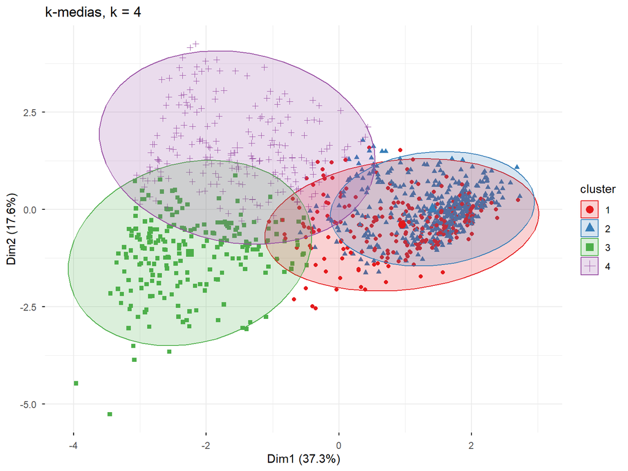

```r
fviz_cluster(km, data = df_z, geom = "point", ellipse.type = "norm",
             palette = "Set1", ggtheme = theme_minimal(),
             main = paste("k-medias, k =", k))
```

## 9. k-medoides (PAM)

```r
pam_res <- pam(df_z, k = k, metric = "manhattan")
table(pam_res$clustering)
```

```
##
##   1   2   3   4
## 441 165 231 265
```

Los medoides son municipios reales que representan a cada grupo:

```r
# >>> CORREGIDO: antes se usaba as.numeric() sobre el código del municipio, que borra
# el 0 inicial ("05001" -> 5001) y haría desaparecer medoides de Antioquia o Atlántico.
# Ahora se toman las filas directamente (mun, df y df_z tienen el mismo orden).
mun[pam_res$id.med, ] %>%
  mutate(cluster = seq_len(k)) %>%
  select(cluster, dep, mun, area_total, n_cultivos, pct_perm,
         pct_cereales, pct_frutales, pct_tropicales, pct_raices) %>%
  kable(digits = 2) %>% kable_styling(bootstrap_options = "striped")
```

| cluster | dep | mun | area_total | n_cultivos | pct_perm | pct_cereales | pct_frutales | pct_tropicales | pct_raices |
| --- | --- | --- | --- | --- | --- | --- | --- | --- | --- |
| 1 | Nariño | Taminango | 2663.89 | 16 | 0.92 | 0.02 | 0.27 | 0.66 | 0.00 |
| 2 | Nariño | El Rosario | 3078.58 | 14 | 0.93 | 0.03 | 0.67 | 0.26 | 0.01 |
| 3 | Bolívar | Morales | 6098.97 | 11 | 0.43 | 0.42 | 0.05 | 0.10 | 0.07 |
| 4 | Boyacá | Caldas | 1043.00 | 11 | 0.07 | 0.23 | 0.07 | 0.00 | 0.45 |

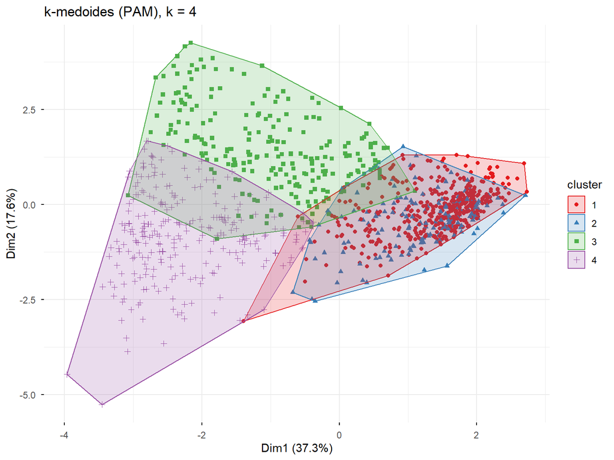

```r
fviz_cluster(pam_res, geom = "point", ellipse.type = "convex",
             palette = "Set1", ggtheme = theme_minimal(),
             main = paste("k-medoides (PAM), k =", k))
```

## 10. Comparación de métodos

```r
sil_km  <- silhouette(km$cluster, dist(df_z))
sil_pam <- silhouette(pam_res$clustering, dist(df_z))

data.frame(Método = c("k-medias", "k-medoides"),
           `Silueta media` = c(mean(sil_km[, 3]), mean(sil_pam[, 3])),
           `% silueta negativa` = 100 * c(mean(sil_km[, 3] < 0), mean(sil_pam[, 3] < 0)),  # >>> NUEVO
           check.names = FALSE) %>%
  kable(digits = 3) %>% kable_styling(bootstrap_options = "striped", full_width = FALSE)
```

| Método | Silueta media | % silueta negativa |
| --- | --- | --- |
| k-medias | 0.255 | 4.446 |
| k-medoides | 0.247 | 10.980 |

```r
# >>> NUEVO: silueta de PAM con su propia distancia (Manhattan), como referencia
pam_res$silinfo$avg.width
```

```
## [1] 0.2578501
```

Tabla de correspondencia entre ambos métodos (qué tanto coinciden las asignaciones):

```r
table(kmedias = km$cluster, kmedoides = pam_res$clustering)
```

```
##        kmedoides
## kmedias   1   2   3   4
##       1  55 165  24   8
##       2 383   0  31   1
##       3   3   0   3 216
##       4   0   0 173  40
```

```r
# >>> NUEVO: índice de Rand ajustado (reporte: 0,667), sin paquetes adicionales
ari <- function(a, b) {
  tab <- table(a, b); n <- sum(tab)
  s   <- sum(choose(tab, 2))
  sa  <- sum(choose(rowSums(tab), 2))
  sb  <- sum(choose(colSums(tab), 2))
  esp <- sa * sb / choose(n, 2)
  (s - esp) / ((sa + sb) / 2 - esp)
}
ari(km$cluster, pam_res$clustering)
```

```
## [1] 0.6667293
```

```r
p_a <- fviz_silhouette(sil_km)  + ggtitle("Silueta: k-medias")
```

```
##   cluster size ave.sil.width
## 1       1  252          0.22
## 2       2  415          0.29
## 3       3  222          0.17
## 4       4  213          0.31
```

```r
p_b <- fviz_silhouette(sil_pam) + ggtitle("Silueta: k-medoides")
```

```
##   cluster size ave.sil.width
## 1       1  441          0.30
## 2       2  165          0.32
## 3       3  231          0.20
## 4       4  265          0.16
```

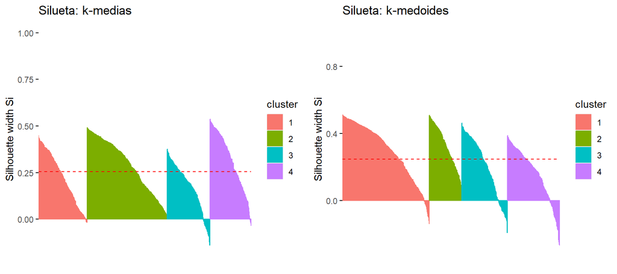

```r
grid.arrange(p_a, p_b, ncol = 2)
```

### 10.1 Sensibilidad a los valores atípicos

```r
# >>> NUEVO: ¿cambia k-medias si se quitan los municipios extremos de la sección 6.1?
keep <- !rownames(df) %in% atip
set.seed(2026)
km_s <- kmeans(scale(df[keep, ]), centers = k, nstart = 50)
ari(km_s$cluster, km$cluster[keep])   # cercano a 1 = los atípicos casi no influyen
```

```
## [1] 0.9657554
```

## 11. Caracterización de los grupos

```r
# >>> NUEVO: nombre de cada grupo según su tipo de cultivo dominante,
# para que el mismo perfil tenga el mismo nombre en k-medias y en PAM
etiquetar <- function(cl) {
  dom <- mun %>%
    mutate(cl = cl) %>%
    group_by(cl) %>%
    summarise(Frutícola = mean(pct_frutales), Cerealero = mean(pct_cereales),
              Andino    = mean(pct_raices),   Tropical  = mean(pct_tropicales)) %>%
    pivot_longer(-cl) %>%
    group_by(cl) %>%
    slice_max(value, n = 1, with_ties = FALSE)
  factor(dom$name[match(cl, dom$cl)],
         levels = c("Frutícola", "Cerealero", "Andino", "Tropical"))
}
mun$cluster_km  <- factor(km$cluster)
mun$cluster_pam <- factor(pam_res$clustering)
mun$perfil_km   <- etiquetar(km$cluster)
mun$perfil_pam  <- etiquetar(pam_res$clustering)
stopifnot(n_distinct(mun$perfil_km) == 4, n_distinct(mun$perfil_pam) == 4)

table(k_medias = mun$perfil_km, k_medoides = mun$perfil_pam)
```

```
##            k_medoides
## k_medias    Frutícola Cerealero Andino Tropical
##   Frutícola       165        24      8       55
##   Cerealero         0       173     40        0
##   Andino            0         3    216        3
##   Tropical          0        31      1      383
```

Perfiles en unidades originales (partición de k-medias):

```r
gran_total_nacional <- sum(mun$area_total, na.rm = TRUE)
mun %>%
  group_by(perfil_km) %>%
  summarise(n = n(),
            pct_area_nacional = 100 * sum(area_total, na.rm = TRUE) / gran_total_nacional,  # >>> NUEVO
            area_mediana = median(area_total),
            n_cultivos   = mean(n_cultivos),
            pct_perm     = mean(pct_perm),
            pct_cereales = mean(pct_cereales),
            pct_frutales = mean(pct_frutales),
            pct_tropicales = mean(pct_tropicales),
            pct_raices   = mean(pct_raices),
            pct_hortalizas = mean(pct_hortalizas)) %>%
  kable(digits = 2, caption = "Perfil promedio por grupo (k-medias)") %>%
  kable_styling(bootstrap_options = c("striped","hover"))
```

Perfil promedio por grupo (k-medias)

| perfil_km | n | pct_area_nacional | area_mediana | n_cultivos | pct_perm | pct_cereales | pct_frutales | pct_tropicales | pct_raices | pct_hortalizas |
| --- | --- | --- | --- | --- | --- | --- | --- | --- | --- | --- |
| Frutícola | 252 | 17.81 | 2159.48 | 15.11 | 0.80 | 0.08 | 0.54 | 0.24 | 0.06 | 0.03 |
| Cerealero | 213 | 33.07 | 4159.00 | 12.10 | 0.24 | 0.53 | 0.11 | 0.06 | 0.15 | 0.03 |
| Andino | 222 | 7.07 | 982.20 | 13.71 | 0.14 | 0.11 | 0.10 | 0.04 | 0.45 | 0.19 |
| Tropical | 415 | 42.06 | 3326.01 | 16.75 | 0.87 | 0.05 | 0.17 | 0.65 | 0.03 | 0.02 |

```r
# >>> NUEVO: los 4 cultivos con más área sembrada dentro de cada grupo (Tabla 3 del reporte)
d25 %>%
  inner_join(select(mun, cod_mun, perfil_km), by = "cod_mun") %>%
  group_by(perfil_km, cultivo) %>%
  summarise(ha = sum(sembrada, na.rm = TRUE), .groups = "drop_last") %>%
  mutate(pct = round(100 * ha / sum(ha), 1)) %>%
  slice_max(pct, n = 4) %>%
  kable(digits = 1, caption = "Cultivos con más área por grupo (k-medias)") %>%
  kable_styling(bootstrap_options = "striped")
```

Cultivos con más área por grupo (k-medias)

| perfil_km | cultivo | ha | pct |
| --- | --- | --- | --- |
| Frutícola | Plátano | 241044.6 | 24.2 |
| Frutícola | Café | 133542.0 | 13.4 |
| Frutícola | Aguacate | 85859.3 | 8.6 |
| Frutícola | Banano | 76114.6 | 7.6 |
| Cerealero | Arroz | 626241.1 | 33.8 |
| Cerealero | Maíz | 413947.2 | 22.3 |
| Cerealero | Palma de aceite | 238048.1 | 12.9 |
| Cerealero | Yuca | 125943.2 | 6.8 |
| Andino | Papa | 176353.4 | 44.6 |
| Andino | Yuca | 32977.2 | 8.3 |
| Andino | Maíz | 28247.0 | 7.1 |
| Andino | Arveja | 21555.5 | 5.4 |
| Tropical | Café | 660724.6 | 28.0 |
| Tropical | Caña | 455417.2 | 19.3 |
| Tropical | Palma de aceite | 427140.4 | 18.1 |
| Tropical | Cacao | 184661.9 | 7.8 |

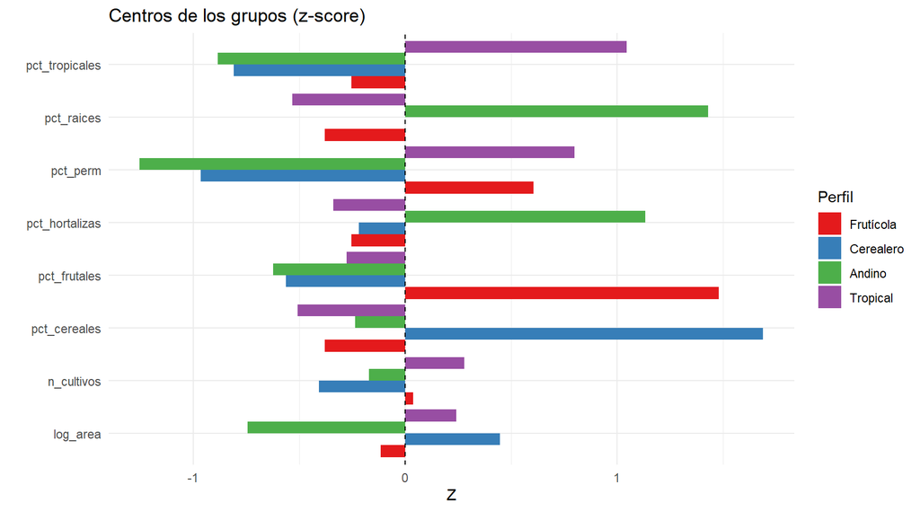

```r
# >>> CORREGIDO: nombres de perfil en vez de números
lab_km <- sapply(1:k, function(i) as.character(mun$perfil_km[km$cluster == i][1]))
centros <- as.data.frame(km$centers) %>%
  mutate(cluster = factor(lab_km, levels = levels(mun$perfil_km))) %>%
  pivot_longer(-cluster, names_to = "variable", values_to = "z")

ggplot(centros, aes(variable, z, fill = cluster)) +
  geom_col(position = "dodge") +
  geom_hline(yintercept = 0, linetype = "dashed") +
  coord_flip() +
  scale_fill_brewer(palette = "Set1") +
  theme_minimal() +
  labs(title = "Centros de los grupos (z-score)", x = "", y = "Z", fill = "Perfil")
```

```r
# >>> NUEVO: varianza explicada y cargas de los dos primeros componentes principales
pca <- prcomp(df_z)
round(100 * summary(pca)$importance[2, 1:2], 1)   # reporte: 37,3 % y 17,6 %
```

```
##  PC1  PC2
## 37.3 17.6
```

```r
round(pca$rotation[, 1:2], 2)                      # qué variables pesan en cada componente
```

```
##                  PC1   PC2
## log_area        0.17  0.61
## n_cultivos      0.22 -0.02
## pct_perm        0.56 -0.07
## pct_cereales   -0.31  0.60
## pct_frutales    0.27 -0.17
## pct_tropicales  0.45 -0.06
## pct_raices     -0.41 -0.18
## pct_hortalizas -0.27 -0.45
```

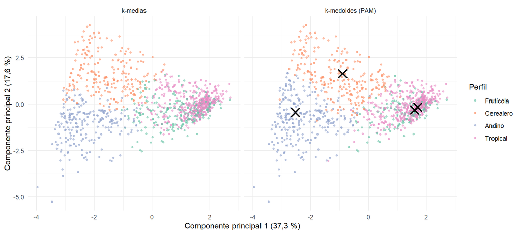

```r
# >>> NUEVO: Figura 5 del reporte en R, con los mismos colores que la Figura 6
pc <- as.data.frame(pca$x[, 1:2]) %>%
  mutate(`k-medias` = mun$perfil_km,
         `k-medoides (PAM)` = mun$perfil_pam) %>%
  pivot_longer(c(`k-medias`, `k-medoides (PAM)`),
               names_to = "metodo", values_to = "perfil")

medoides_pc <- as.data.frame(pca$x[pam_res$id.med, 1:2]) %>%
  mutate(metodo = "k-medoides (PAM)")

ggplot(pc, aes(PC1, PC2, color = perfil)) +
  geom_point(size = 1, alpha = 0.6) +
  geom_point(data = medoides_pc, aes(PC1, PC2), inherit.aes = FALSE,
             shape = 4, size = 4, stroke = 1.5, color = "black") +
  facet_wrap(~ metodo) +
  scale_color_brewer(palette = "Set2") +
  theme_minimal() +
  labs(x = "Componente principal 1 (37,3 %)",
       y = "Componente principal 2 (17,6 %)",
       color = "Perfil")
```

Ver los grupos por departamento:

```r
# >>> CORREGIDO: columnas en orden y con nombre, 12 departamentos como en el reporte
mun %>%
  count(dep, perfil_km) %>%
  pivot_wider(names_from = perfil_km, values_from = n, values_fill = 0, names_sort = TRUE) %>%
  mutate(Total = rowSums(across(where(is.numeric)))) %>%
  arrange(desc(Total)) %>%
  head(12) %>%
  kable(caption = "Municipios por grupo en los 12 departamentos con más municipios") %>%
  kable_styling(bootstrap_options = "striped")
```

Municipios por grupo en los 12 departamentos con más municipios

| dep | Frutícola | Cerealero | Andino | Tropical | Total |
| --- | --- | --- | --- | --- | --- |
| Antioquia | 40 | 12 | 13 | 60 | 125 |
| Boyacá | 16 | 9 | 71 | 27 | 123 |
| Cundinamarca | 26 | 7 | 50 | 33 | 116 |
| Santander | 11 | 3 | 10 | 63 | 87 |
| Nariño | 14 | 2 | 21 | 27 | 64 |
| Tolima | 12 | 18 | 0 | 17 | 47 |
| Bolívar | 4 | 32 | 7 | 3 | 46 |
| Cauca | 5 | 0 | 3 | 34 | 42 |
| Valle del Cauca | 15 | 0 | 0 | 27 | 42 |
| Norte de Santander | 4 | 5 | 8 | 23 | 40 |
| Huila | 1 | 5 | 0 | 31 | 37 |
| Chocó | 27 | 4 | 0 | 0 | 31 |

```r
# >>> NUEVO: verificar La Guajira (reporte: 11 de 15 cerealeros)
mun %>% filter(dep == "La Guajira") %>% count(perfil_km)
```

```
## # A tibble: 4 × 2
##   perfil_km     n
##   <fct>     <int>
## 1 Frutícola     1
## 2 Cerealero    11
## 3 Andino        2
## 4 Tropical      1
```

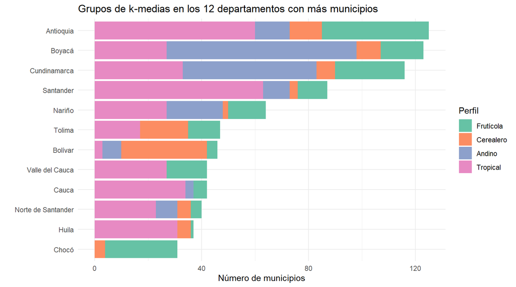

```r
# >>> NUEVO: figura de departamentos (Figura 6 del reporte) generada en R
top12 <- mun %>% count(dep, sort = TRUE) %>% head(12) %>% pull(dep)
mun %>%
  filter(dep %in% top12) %>%
  count(dep, perfil_km) %>%
  ggplot(aes(x = reorder(dep, n, sum), y = n, fill = perfil_km)) +
  geom_col() +
  coord_flip() +
  scale_fill_brewer(palette = "Set2") +
  theme_minimal() +
  labs(x = "", y = "Número de municipios", fill = "Perfil",
       title = "Grupos de k-medias en los 12 departamentos con más municipios")
```

## 12. Interpretación y conclusiones

1. A partir de ocho variables cuantitativas construidas con datos reales de las EVA 2025, los 1.102 municipios se agrupan en cuatro perfiles productivos: tropical tradicional, cerealero de ciclo corto, frutícola permanente y andino de pequeña escala.
2. Ambos métodos identifican esos perfiles. Coinciden en 85,0 % de los municipios (índice de Rand ajustado de 0,667) y difieren sobre todo en los municipios de composición mixta, en particular los frutícolas.
3. La estructura de los grupos es entre débil y no sustancial (silueta media de 0,255 con k-medias y 0,247 con k-medoides), por lo que los perfiles deben leerse como tendencias dominantes y no como categorías cerradas.
4. Ninguno de los dos métodos domina: k-medias asigna menos municipios a un grupo con el que comparten poco, pero su ventaja en compacidad es mínima y depende de la distancia usada para medirla; k-medoides aporta municipios representativos que facilitan la interpretación. La elección depende de si se prioriza la cohesión estadística o la comunicación de los resultados.
5. El trabajo puede mejorarse incorporando las oleaginosas, más de un año de datos y variables territoriales, y probando otros criterios de validación del número de grupos.

## 13. Limitaciones

- Los datos son reportados por los municipios y conciliados por la UPRA; no son mediciones directas.
- Las cifras de los últimos años pueden ajustarse.
- El análisis usa un solo año (2025), por lo que no captura dinámica temporal.
- El área es acumulada anual: permanentes más ambos semestres de los transitorios.

## Referencias

Hartigan, J. A. y Wong, M. A. (1979). Algorithm AS 136: A k-means clustering algorithm. *Applied Statistics*, 28(1), 100-108.

Hubert, L. y Arabie, P. (1985). Comparing partitions. *Journal of Classification*, 2(1), 193-218.

Kaufman, L. y Rousseeuw, P. (1990). *Finding Groups in Data*. Wiley.

MacQueen, J. (1967). Some methods for classification and analysis of multivariate observations.

Rousseeuw, P. (1987). Silhouettes: a graphical aid to the interpretation and validation of cluster analysis. *Journal of Computational and Applied Mathematics*, 20.

UPRA. Evaluaciones Agropecuarias Municipales (EVA) 2019-2025. Base Agrícola. datos.gov.co.